# Practical-Machine-Learning-Course-Project

-Six young health participants were asked to perform one set of 10 repetitions of the Unilateral Dumbbell Biceps Curl in five different fashions: exactly according to the specification (Class A), throwing the elbows to the front (Class B), lifting the dumbbell only halfway (Class C), lowering the dumbbell only halfway (Class D) and throwing the hips to the front (Class E). Class A corresponds to the specified execution of the exercise, while the other 4 classes correspond to common mistakes. Participants were supervised by an experienced weight lifter to make sure the execution complied to the manner they were supposed to simulate. The exercises were performed by six male participants aged between 20-28 years, with little weight lifting experience. We made sure that all participants could easily simulate the mistakes in a safe and controlled manner by using a relatively light dumbbell (1.25kg). Read more: http://groupware.les.inf.puc-rio.br/har

## The following plots are random forest, gbm and knn fitted accuracies from training dataset with 5 folds cross validations.

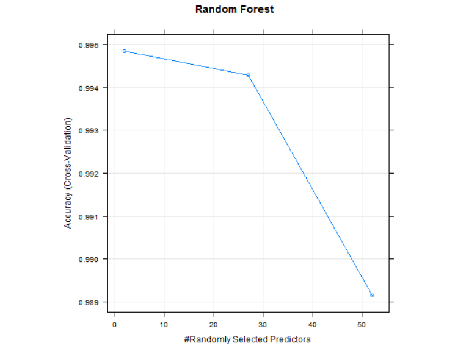

```r
library(png)
img <- readPNG("random-forest.png")
grid::grid.raster(img)
```

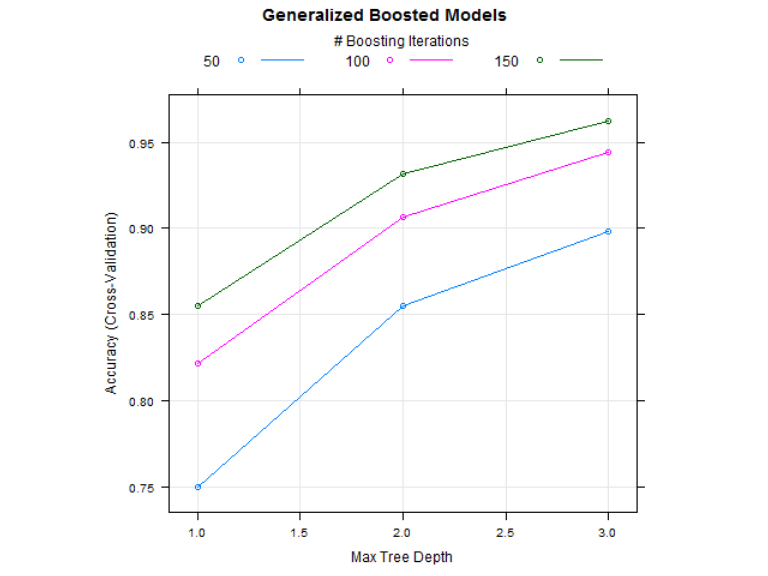

```r
library(png)
img <- readPNG("gbm.png")
grid::grid.raster(img)
```

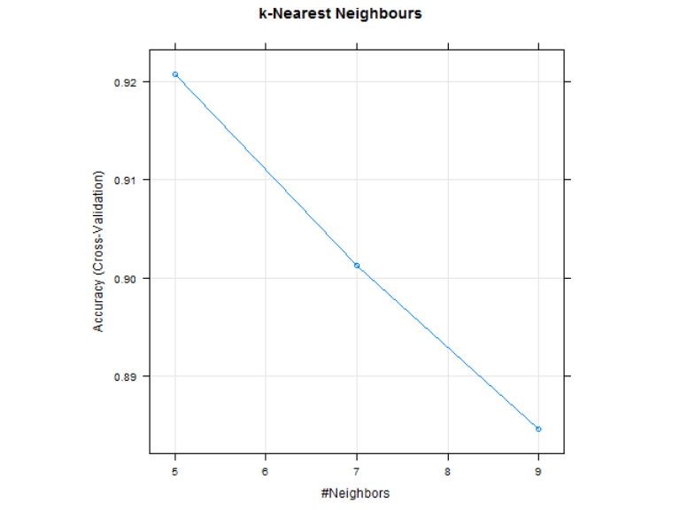

```r
library(png)
img <- readPNG("knn.png")
grid::grid.raster(img)
```

## The following lists are some classification results on the dataset

```r
rx <- read.table("results.txt")
colnames(rx) <- c("matches","methods")
rx
```

```
##    matches       methods
## 1       20 random_forest
## 2       20           gbm
## 3       20           knn
## 4       20           C50
## 5        9          nnet
## 6        7           elm
## 7       14          lda2
## 8       11           sda
## 9        8         rpart
## 10      20       treebag
## 11      13           pls
## 12      12      bayesglm
## 13      19         ctree
## 14       7           rbf
## 15      14           lvq
## 16      20          kknn
## 17      12      multinom
## 18      19      gcvEarth
```